# HDBSCAN

Erik Larsen

2026-03-24

# Overview

This vignette was developed to formally document an ad-hoc cluster analysis for TMEM184B immunoprecipitation tandem mass-spec (IP-MS/MS) based on experiments for **Dr. Martha Bhattacharya’s lab** at the **University of Arizona** for the endolysosomal paper under revision (2025-02-28) for the Journal of Cell Science

## Attach Packages

```r
# data/wrangling
library(tidyverse)
library(Endo)
library(DT)

  ## (hdbscan)
library(dbscan)

# GSEA/viz
library(clusterProfiler)
library(org.Hs.eg.db)
library(ReactomePA)
library(AnnotationDbi)
library(cowplot)

# progress bar
library(progressr)

# parallelization
library(future)
library(future.apply)

# network viz
library(visNetwork)

options(stringsAsFactors = FALSE)
```

## Load the Pre-Computed Data

Classify each protein into a quadrant based on its `hSAINT` score ( **> 0.5** = **High hSAINT**) and aggregate number of `contamination flags` (e.g. `identified in literature` as contaminant or `identified in > 5% CRAPome` studies = **high contamination**, otherwise, **low**)

```r
# Load precomputed objects from preprocessing
load("R/precompute_objects.rda")
```

```r
hSAINT <- hSAINT |>
  dplyr::mutate(protein_stat_class = dplyr::case_when(score > 0.5 &
                                                lit_flag + CRAPome_flag < 1 ~ 'High hSAINT, Low Contamination',
                                              score < 0.5 &
                                                lit_flag + CRAPome_flag < 1 ~ 'Low hSAINT, Low Contamination',
                                              score > 0.5 &
                                                lit_flag + CRAPome_flag > 0 ~ 'High hSAINT, High Contamination',
                                              score < 0.5 &
                                                lit_flag + CRAPome_flag > 0 ~ 'Low hSAINT, High Contamination'),
                contam_flag = lit_flag + CRAPome_flag) |>
  dplyr::rename(protein_hSAINT_score = score) |>
  dplyr::rename_with(.cols = c(dplyr::contains("flag")), ~paste0('protein_', .x)) |>
  dplyr::relocate(protein_contam_flag, .after = protein_hSAINT_score)
```

# Principal Component Analysis

Conduct **PCA** on the `IPMS counts dataframe` to extract the 2-D matrix required by `hdbscan`

```r
pca <- stats::prcomp(IPMS_counts[,2:ncol(IPMS_counts)], scale = T)

X <- pca$x[ , 1:2, drop = FALSE]
```

# Clustering

## Detect Clusters

Pass the two-dimensional object through `HDBSCAN` to obtain clustering results

- set `minPts` (minimum number of points required to form a dense region) to default (**10**), which provides a stable balance between detecting meaningful dense regions and avoiding fragmentation

`HDBSCAN` will identify clusters from the 2-D object as regions of high point density within the embedding

```r
hdb <- dbscan::hdbscan(x = X, minPts = 10)
```

## Extract Clusters

```r
cluster_labels <- hdb$cluster
```

## Tabulate Clusters

```r
cluster_table <- table(cluster_labels)

cluster_labels |>
  as.data.frame() |>
  dplyr::mutate(cluster_labels = as.character(cluster_labels)) |>
  dplyr::group_by(cluster_labels) |>
  dplyr::summarize(n = dplyr::n()) |>
  dplyr::arrange(desc(n)) |>
  dplyr::mutate(cluster_labels = dplyr::case_when(cluster_labels == '0' ~ 'noise',
                                                  TRUE ~ cluster_labels)) |>
  head()
```

```
## # A tibble: 6 × 2
##   cluster_labels     n
##   <chr>          <int>
## 1 47              2905
## 2 noise           2580
## 3 36                50
## 4 33                43
## 5 45                40
## 6 24                38
```

# Cluster Visualization

Plot the PCs

## PCA Plot

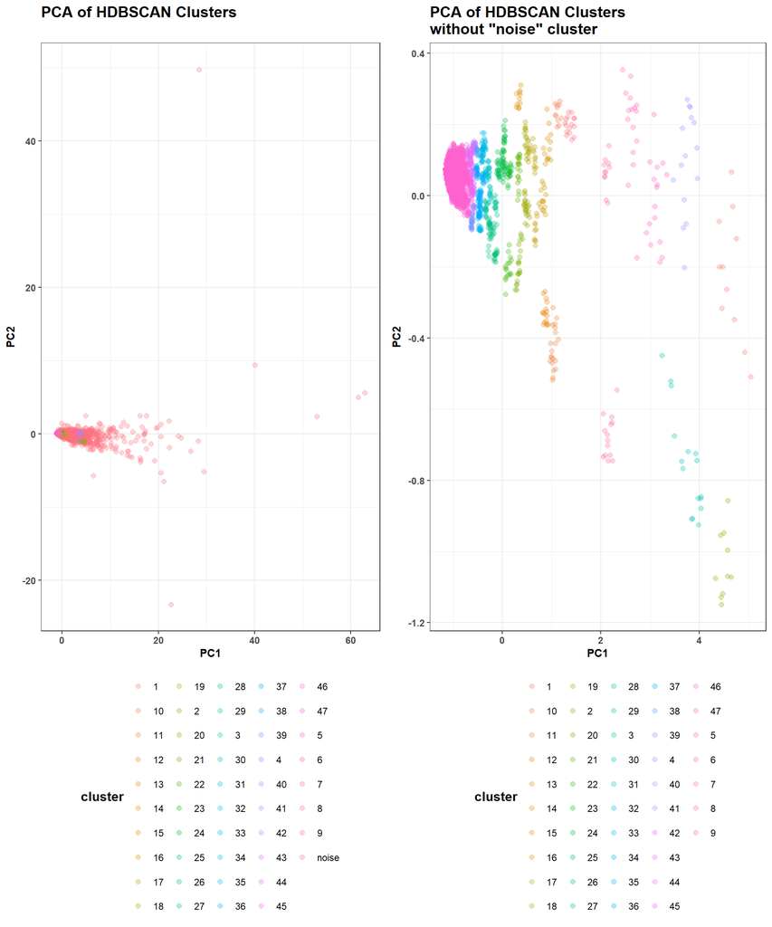

```r
pca_results_df <- tibble::tibble(
  PC1 = X[ , 1],
  PC2 = X[ , 2],
  cluster = cluster_labels |>
                     as.data.frame() |>
                     dplyr::mutate(cluster_labels = as.character(
                       cluster_labels
                     ),
                     cluster_labels = dplyr::case_when(cluster_labels == '0' ~
                                                         'noise',
                                                       TRUE ~
                                                         cluster_labels)) |>
                     dplyr::pull()
)

cowplot::plot_grid(
  pca_results_df |>
    ggplot2::ggplot(ggplot2::aes(x = PC1, y = PC2, group = cluster, color = cluster)) +
    ggplot2::geom_point(size = 2, alpha = 0.3) +
    ggplot2::labs(
      title = 'PCA of HDBSCAN Clusters'
      ) +
    ggplot2::theme_bw() +
    ggplot2::theme(title = ggplot2::element_text(face = 'bold', size = 12),
                   axis.title = ggplot2::element_text(face = 'bold', size = 10),
                   axis.text = ggplot2::element_text(face = 'bold', size = 9),
                   legend.position = 'bottom',
                   legend.direction = 'horizontal',
                   legend.spacing.x = unit(0.5, 'cm'))
  ,
  pca_results_df |>
    dplyr::filter(cluster != 'noise') |>
    ggplot2::ggplot(ggplot2::aes(x = PC1, y = PC2, group = cluster, color = cluster)) +
    ggplot2::geom_point(size = 2, alpha = 0.3) +
    ggplot2::labs(
      title = 'PCA of HDBSCAN Clusters\nwithout "noise" cluster'
      ) +
    ggplot2::theme_bw() +
    ggplot2::theme(title = ggplot2::element_text(face = 'bold', size = 12),
                   axis.title = ggplot2::element_text(face = 'bold', size = 10),
                   axis.text = ggplot2::element_text(face = 'bold', size = 9),
                   legend.position = 'bottom',
                   legend.direction = 'horizontal',
                   legend.spacing.x = unit(0.5, 'cm'))
    ,
  ncol = 2,
  align = 'h'
)
```

# Cluster Descriptions

In order to assess this method and also to compare/validate the `hierarchical SAINT Poisson mixture model`, describing clusters based on the proteins within them is useful

Similarly-localized proteins could be expected to have similar abundances to each other as well as the target (**TMEM184B**)

Similarly-functioning proteins could also be expected to have similar abundances to each other as well as the target

Describing these clusters attained by `HDBSCAN` via gene ontology gene set enrichment analysis is, therefore, useful and standard practice

Furthermore, we may be able to assemble a `protein-protein interaction network` from the results

I outline this below– the methods and results for acquiring these clusters, their constituent proteins, and how we make sense of them– visualized as `dotplots`, `heatmaps`, and a `network`. I include searchable tables printed last

## Extract Clusters

Extract gene names from the `PCA and HDBSCAN`-derived clusters and convert to a dataframe

```r
clusters_df <- pca_results_df |>
  dplyr::select(cluster) |>
  dplyr::mutate(Protein = IPMS_counts |> dplyr::pull(Protein), .before = 1)

rm(list = c('X', 'pca_results_df', 'pca'))
head(clusters_df)
```

```
## # A tibble: 6 × 2
##   Protein cluster
##   <chr>   <chr>
## 1 A2M     noise
## 2 A2ML1   47
## 3 AAAS    noise
## 4 AACS    47
## 5 AAK1    noise
## 6 AAMDC   47
```

## Join Clusters to hSAINT

Include score summaries (mean and median posterior probability scores, ranks, and literature or CRAPome contamination rate)

```r
cluster_scores <- clusters_df |>
  dplyr::inner_join(
    hSAINT
  ) |>
  dplyr::arrange(desc(protein_hSAINT_score)) |>
  dplyr::group_by(cluster) |>
  dplyr::summarize(cluster_mean_hSAINT_score = mean(protein_hSAINT_score),
                   cluster_median_hSAINT_score = stats::median(protein_hSAINT_score),
                   cluster_hSAINT_score_mass = sum(protein_hSAINT_score),
                   cluster_size = dplyr::n(),
                   cluster_lit_flag_perc = (sum(protein_lit_flag)/cluster_size)*100,
                   cluster_CRAPome_flag_perc = (sum(protein_CRAPome_flag)/cluster_size)*100,
                   cluster_contam_perc = cluster_lit_flag_perc + cluster_CRAPome_flag_perc) |>
  dplyr::arrange(desc(cluster_mean_hSAINT_score), cluster_contam_perc) |>
  dplyr::mutate(cluster_mean_rank = dplyr::row_number()) |>
  dplyr::arrange(desc(cluster_median_hSAINT_score), cluster_contam_perc) |>
  dplyr::mutate(cluster_median_rank = dplyr::row_number()) |>
  dplyr::arrange(desc(cluster_hSAINT_score_mass), cluster_contam_perc) |>
  dplyr::mutate(cluster_total_rank = dplyr::row_number()) |>
  dplyr::arrange(cluster_mean_rank) |>
  dplyr::relocate(c(cluster_lit_flag_perc, cluster_CRAPome_flag_perc), .after = cluster_total_rank)

head(cluster_scores)
```

```
## # A tibble: 6 × 11
##   cluster cluster_mean_hSAINT_sc…¹ cluster_median_hSAIN…² cluster_hSAINT_score…³
##   <chr>                      <dbl>                  <dbl>                  <dbl>
## 1 2                          1.000                  1.000                  10.00
## 2 1                          1.000                  1.000                  11.0
## 3 3                          1.000                  1.000                  16.0
## 4 4                          1.000                  1.000                  15.0
## 5 5                          1.000                  1.000                  17.0
## 6 8                          1.000                  1.000                  11.0
## # ℹ abbreviated names: ¹cluster_mean_hSAINT_score,
## #   ²cluster_median_hSAINT_score, ³cluster_hSAINT_score_mass
## # ℹ 7 more variables: cluster_size <int>, cluster_contam_perc <dbl>,
## #   cluster_mean_rank <int>, cluster_median_rank <int>,
## #   cluster_total_rank <int>, cluster_lit_flag_perc <dbl>,
## #   cluster_CRAPome_flag_perc <dbl>
```

Join the cluster scores data to the cluster (per protein) dataframe and the `hSAINT` results for classification

```r
protein_cluster_df <- clusters_df |>
  dplyr::inner_join(
    hSAINT
  ) |>
  dplyr::full_join(
    cluster_scores |>
      dplyr::ungroup()
  ) |>
  dplyr::mutate(dplyr::across(c(dplyr::where(is.double)), ~ round(.x, 3))) |>
  dplyr::mutate(
    cluster_class = dplyr::case_when(
      cluster_median_hSAINT_score > 0.5 &
        cluster_contam_perc >
        cluster_scores |>
        dplyr::pull(cluster_contam_perc) |>
        stats::median() ~ 'High hSAINT, High Contamination',
      cluster_median_hSAINT_score > 0.5 &
        cluster_contam_perc <
        cluster_scores |>
        dplyr::pull(cluster_contam_perc) |>
        stats::median() ~ 'High hSAINT, Low Contamination',
      cluster_median_hSAINT_score < 0.5 &
        cluster_contam_perc >
        cluster_scores |>
        dplyr::pull(cluster_contam_perc) |>
        stats::median() ~ 'Low hSAINT, High Contamination',
      cluster_median_hSAINT_score < 0.5 &
        cluster_contam_perc <
        cluster_scores |>
        dplyr::pull(cluster_contam_perc) |>
        stats::median() ~ 'Low hSAINT, Low Contamination'
    )) |>
  dplyr::relocate(cluster_class, .after = cluster) |>
  dplyr::arrange(desc(protein_hSAINT_score), Protein) |>
  dplyr::group_by(cluster) |>
  dplyr::mutate(cluster_clean_n = sum(protein_contam_flag), .after = cluster_size) |>
  dplyr::mutate(cluster_clean_fraction = round((cluster_clean_n/cluster_size)*100, 2), .after = cluster_clean_n) |>
  dplyr::ungroup()

head(protein_cluster_df)
```

```
## # A tibble: 6 × 20
##   Protein cluster cluster_class         protein_hSAINT_score protein_contam_flag
##   <chr>   <chr>   <chr>                                <dbl>               <dbl>
## 1 AAAS    noise   High hSAINT, High Co…                    1                   0
## 2 AARS1   noise   High hSAINT, High Co…                    1                   0
## 3 AARS2   noise   High hSAINT, High Co…                    1                   0
## 4 AASS    noise   High hSAINT, High Co…                    1                   0
## 5 ABCB10  noise   High hSAINT, High Co…                    1                   0
## 6 ABCB7   noise   High hSAINT, High Co…                    1                   0
## # ℹ 15 more variables: protein_lit_flag <dbl>, protein_CRAPome_flag <dbl>,
## #   protein_stat_class <chr>, cluster_mean_hSAINT_score <dbl>,
## #   cluster_median_hSAINT_score <dbl>, cluster_hSAINT_score_mass <dbl>,
## #   cluster_size <int>, cluster_clean_n <dbl>, cluster_clean_fraction <dbl>,
## #   cluster_contam_perc <dbl>, cluster_mean_rank <int>,
## #   cluster_median_rank <int>, cluster_total_rank <int>,
## #   cluster_lit_flag_perc <dbl>, cluster_CRAPome_flag_perc <dbl>
```

## Cluster GO GSEA

```r
EntrezIDs <- AnnotationDbi::select(
  org.Hs.eg.db,
  keys = clusters_df |> dplyr::distinct(Protein) |> dplyr::pull(),
  columns = 'ENTREZID',
  keytype = 'SYMBOL'
) |>
  dplyr::filter(!is.na(2))

EntrezMap <- stats::setNames(EntrezIDs$ENTREZID, EntrezIDs$SYMBOL)
```

Create enrichment functions

```r
background_genes <- EntrezIDs |> # use the EntrezIDs mapped from the modules_df
  dplyr::filter(!is.na(ENTREZID)) |>
  dplyr::pull(ENTREZID)

get_GO <- function(genes, ontology, background_genes) {
  clusterProfiler::enrichGO(
    gene = genes,
    universe = background_genes,
    OrgDb = org.Hs.eg.db,
    keyType = 'ENTREZID',
    ont = ontology,
    pAdjustMethod = 'BH',
    qvalueCutoff = 0.05,
    readable = T
  )
}

get_kegg <- function(genes, EntrezMap) {
  entrez <- EntrezMap[genes]
  entrez <- entrez[!is.na(entrez)]
  if (length(entrez)==0) {
    return(NULL)
  }
  clusterProfiler::enrichKEGG(
    gene = entrez,
    organism = 'hsa',
    pAdjustMethod = 'BH',
    qvalueCutoff = 0.05
  )
}

get_reactome <- function(genes, EntrezMap) {
  entrez <- EntrezMap[genes]
  entrez <- entrez[!is.na(entrez)]
  if (length(entrez)==0) {
    return(NULL)
  }
  ReactomePA::enrichPathway(
    gene = entrez,
    organism = 'human',
    pAdjustMethod = 'BH',
    qvalueCutoff = 0.05,
    readable = T
  )
}
```

Run the functions on the dataset in parallel (multiple CPUs)

```r
future::plan(future::multisession, workers = 6)
progressr::handlers(progressr::handler_txtprogressbar())

cluster_ids <- sort(unique(clusters_df$cluster))

progressr::with_progress({
  p <- progressr::progressor(steps = length(cluster_ids))

  enrichment_results <- future.apply::future_lapply(
    cluster_ids,
    function(mod) {

      # tick the progress bar
      p(sprintf("cluster %s", mod))

      suppressPackageStartupMessages({
          library(clusterProfiler)
          library(DOSE)
          library(org.Hs.eg.db)
          library(dplyr)
        })

        get_GO <- get_GO   # export the function so it's recognized for parallelization
        protein_cluster_df <- protein_cluster_df
        clusters_df <- clusters_df

        # proteins without any contamination except for one cluster
        genes <- clusters_df |>
          dplyr::filter(cluster == mod) |>
          dplyr::inner_join(EntrezIDs |>
                              dplyr::rename(Protein = 1)) |> # get ENTREZID's
          dplyr::inner_join(protein_cluster_df |>
                                dplyr::filter((cluster_median_hSAINT_score > 0.5 &
                                                 cluster_clean_fraction < 5 &
                                                 protein_contam_flag < 2 ) |
                                                protein_contam_flag == 0) |>
                              dplyr::distinct(Protein)) |> # filter out any proteins ID'd in literature or in > 5% of CRAPome studies as contaminants

          dplyr::distinct(ENTREZID) |>
          dplyr::pull(ENTREZID)

      # all proteins within a given cluster
        background_genes <- clusters_df |>
          dplyr::filter(cluster == mod) |>
          dplyr::inner_join(EntrezIDs |>
                              dplyr::rename(Protein = 1)) |>
          dplyr::distinct(ENTREZID) |>
          dplyr::pull()

      list(
        cluster = mod,
        go_bp  = get_GO(genes, ontology = "BP", background_genes = background_genes),
        go_cc  = get_GO(genes, ontology = "CC", background_genes = background_genes),
        go_mf  = get_GO(genes, ontology = "MF", background_genes = background_genes)
        # add KEGG/Reactome later
      )
    }
  )
})

names(enrichment_results) <- cluster_ids
rm(p)
```

Gather enrichment results

```r
global_enrichment_results_df <- lapply(enrichment_results, function(x) {
  x %>%
    purrr::map_df(., .f = as.data.frame, .id = 'GO_Category') |>
    dplyr::rename(cluster = 2, GO_Term = Description, GO_ID = ID) |>
    tidyr::fill(cluster, .direction = 'down') |>
    dplyr::filter(!is.na(GO_ID)) |>
    dplyr::mutate(GO_Category = gsub(GO_Category,
                                     pattern = 'go_',
                                     replacement = '') %>%
                    stringr::str_to_upper(.)) |>
    tibble::remove_rownames() |>
    dplyr::distinct()
  }
) %>%
  purrr::map_df(., .f = as.data.frame) |>  # join to the scores and hSAINT classes
  dplyr::full_join(cluster_scores) |>
  dplyr::filter(!is.na(GO_Category)) |>
  dplyr::inner_join(
    protein_cluster_df |>
      dplyr::distinct(cluster, cluster_class)
  ) |>
  dplyr::group_by(cluster) |>
  dplyr::arrange(cluster_contam_perc, desc(cluster_median_hSAINT_score), p.adjust) |>
  dplyr::relocate(cluster_class, .after = cluster)

global_enrichment_results_df |>
  head()
```

```
## # A tibble: 6 × 25
## # Groups:   cluster [1]
##   GO_Category cluster cluster_class   GO_ID GO_Term GeneRatio BgRatio RichFactor
##   <chr>       <chr>   <chr>           <chr> <chr>   <chr>     <chr>        <dbl>
## 1 MF          47      Low hSAINT, Lo… GO:0… transc… 288/2660  288/27…      1
## 2 MF          47      Low hSAINT, Lo… GO:0… transf… 457/2660  461/27…      0.991
## 3 CC          47      Low hSAINT, Lo… GO:0… cell p… 364/2665  366/27…      0.995
## 4 CC          47      Low hSAINT, Lo… GO:0… plasma… 349/2665  351/27…      0.994
## 5 CC          47      Low hSAINT, Lo… GO:0… boundi… 393/2665  396/27…      0.992
## 6 CC          47      Low hSAINT, Lo… GO:1… transf… 265/2665  266/27…      0.996
## # ℹ 17 more variables: FoldEnrichment <dbl>, zScore <dbl>, pvalue <dbl>,
## #   p.adjust <dbl>, qvalue <dbl>, geneID <chr>, Count <int>,
## #   cluster_mean_hSAINT_score <dbl>, cluster_median_hSAINT_score <dbl>,
## #   cluster_hSAINT_score_mass <dbl>, cluster_size <int>,
## #   cluster_contam_perc <dbl>, cluster_mean_rank <int>,
## #   cluster_median_rank <int>, cluster_total_rank <int>,
## #   cluster_lit_flag_perc <dbl>, cluster_CRAPome_flag_perc <dbl>
```

Filtering proteins devoid of contamination by literature review or CRAPome frequency substantially alters the GO enrichment of clusters, leaving the larger clusters– typically, the “background” clusters or “clean, signal-less” clusters – to provide the enrichment

**TMEM is clustered into the noise cluster**, likely because of its low-variance counts across treatments and weak correlation with other protein abundances; this is not uncommon for a transmembrane protein with no prior for potential interactors

Using `hierarchical SAINT score` as an explanatory tool, this is likely because the clusters without GO enrichment contained a large mix of proteins scored as “noise” (low posterior probability of being a true interactor) and signal (high posterior probability of being a true interactor)

In order to better make sense of the clustering– describing the **“un-enriched” clusters**– “sub-cluster” GO GSEA was conducted

## SubCluster GO GSEA

Sub-cluster enrichment analysis on clusters without any enrichment (to describe themes of proteins within these clusters)

- To do this, we adapt the method from hierarchical clustering vignette, where a dendrogram is created from the raw counts matrix
- Then we create a local hierarchical tree and index it by filtering *for* the proteins that were not in an enriched cluster

```r
"%notin%" <- Negate("%in%")

# index the clusters without significant enrichment to describe sub-clusters
tier2_clusters <- c(seq(1:48) |> as.character())[
  which(c(seq(1:48) |> as.character()) %notin% c(global_enrichment_results_df |>
          dplyr::distinct(cluster) |>
          dplyr::pull()) == T)]
```

```r
# function to gather sub-clusters for each cluster that did not return enrichment results
subclusters_from_hdbscan <- function(
  counts_mat,
  clusters_df,
  n_sub_per_cluster = 3L
) {
  # extract unique HDBSCAN clusters (exclude noise = 0)
  cluster_ids <- clusters_df |>
    dplyr::filter(cluster != 'noise') |>
    dplyr::distinct(cluster) |> dplyr::pull()

  # list to store subcluster assignments
  out_list <- vector("list", length(cluster_ids))
  names(out_list) <- as.character(cluster_ids)

  for (k in cluster_ids) {
    # proteins in this cluster
    prots_k <- clusters_df$Protein[clusters_df$cluster == k]

    # subset the counts matrix
    sub_mat <- counts_mat[prots_k, , drop = FALSE]

    # build a local hierarchical tree
    dist_obj <- stats::dist(sub_mat)
    hc_obj   <- stats::hclust(dist_obj, method = "ward.D2")

    # number of subclusters
    K_big <- n_sub_per_cluster

    # finer cut
    sub_labels <- stats::cutree(hc_obj, k = K_big)

    # assemble tibble
    df_k <- tibble::tibble(
      Protein   = prots_k,
      cluster   = k,
      sub_label = sub_labels
    )

    # define subcluster names
    df_k <- df_k %>%
      dplyr::group_by(cluster, sub_label) %>%
      dplyr::mutate(
        subcluster = paste0("sub", dplyr::cur_group_id())
      ) %>%
      dplyr::ungroup()

    out_list[[as.character(k)]] <- df_k
  }

  # combine all clusters
  dplyr::bind_rows(out_list)
}
```

```r
# get the sub-clusters
subclusters_df <- subclusters_from_hdbscan(
  counts_mat  = IPMS_mat,
  clusters_df = dplyr::filter(clusters_df, cluster %in% tier2_clusters),
  n_sub_per_cluster = 3L
)
```

```r
future::plan(future::multisession, workers = 6)
progressr::handlers(progressr::handler_txtprogressbar())

subcluster_enrichment_df <- progressr::with_progress({

  sub_ids <- subclusters_df |> dplyr::distinct(cluster, subcluster)

  p <- progressr::progressor(steps = nrow(sub_ids))

  res_list <- future.apply::future_lapply(
    seq_len(nrow(sub_ids)),
    function(i) {

      library(clusterProfiler)
      library(dplyr)

      get_GO <- get_GO
      subclusters_df <- subclusters_df
      protein_cluster_df <- protein_cluster_df

      cl <- sub_ids$cluster[i]
      sc <- sub_ids$subcluster[i]

      p(sprintf("cluster %s subcluster %s", cl, sc))

      # only genes without any contamination
      genes <- subclusters_df |>
        dplyr::filter(cluster == cl, subcluster == sc) |>
        dplyr::inner_join(
          EntrezIDs |>
            dplyr::filter(!is.na(ENTREZID)) |>
            dplyr::rename(Protein = 1),
          by = "Protein"
        ) |>
        dplyr::inner_join(
          protein_cluster_df |>
            dplyr::filter((cluster_median_hSAINT_score > 0.5 &
                             cluster_clean_fraction < 5 &
                             protein_contam_flag < 2 ) |
                            protein_contam_flag == 0),
          by = "Protein"
        ) |>
        dplyr::distinct(ENTREZID) |>
        dplyr::pull()

      # all genes within a given cluster
      background_genes <- subclusters_df |>
        dplyr::filter(cluster == cl) |>
        dplyr::inner_join(
          EntrezIDs |>
            dplyr::filter(!is.na(ENTREZID)) |>
            dplyr::rename(Protein = 1),
          by = "Protein"
        ) |>
        dplyr::distinct(ENTREZID) |>
        dplyr::pull()

      out <- list()

      for (ont in c("BP", "CC", "MF")) {

        res <- get_GO(genes, ontology = ont, background_genes = background_genes)

        if (!is.null(res)) {
          if (nrow(res@result) > 0) {
            df <- as.data.frame(res)
            if (nrow(df) > 0) {
              df$cluster <- cl
              df$subcluster <- sc
              df$GO_Category <- ont
              out[[length(out) + 1]] <- df
            }
          }
        }
      }

      if (length(out) == 0) {
        return(NULL)
      } else {
        return(dplyr::bind_rows(out))
      }
    }
  )

  dplyr::bind_rows(res_list)
})
```

```r
# wrangle the sub-cluster GO GSEA results
subcluster_enrichment_results_df <- subcluster_enrichment_df |>
  dplyr::rename(GO_ID = ID, GO_Term = Description) |>
  dplyr::relocate(c(cluster, subcluster, GO_Category), .before = 1) |>
  tibble::rowid_to_column('id') |>
  dplyr::filter(!is.na(GO_Category)) |>
  dplyr::select(-id) |>
  dplyr::full_join(
    cluster_scores
  ) |>
  dplyr::inner_join(
    protein_cluster_df |> dplyr::distinct(cluster, cluster_class)
  ) |>
  dplyr::filter(!is.na(GO_Category)) |>
  dplyr::relocate(cluster_class, .after = cluster)

subcluster_enrichment_results_df |>
  head()
```

```
##   cluster                   cluster_class subcluster GO_Category      GO_ID
## 1      36 High hSAINT, High Contamination       sub1          MF GO:0005515
##           GO_Term GeneRatio BgRatio RichFactor FoldEnrichment   zScore
## 1 protein binding     30/30   43/48  0.6976744       1.116279 3.018034
##        pvalue   p.adjust     qvalue
## 1 0.005003784 0.04003027 0.03160285
##                                                                                                                                                                                  geneID
## 1 ABI2/CHD2/CLPB/CPSF6/CSTF1/DERA/DUT/GYS1/HAUS8/HOOK1/INPP4A/INTS10/MAD1L1/MAP7/MYL12B/NCAPH2/NIPSNAP1/PIK3R2/PMVK/RAE1/RASAL2/SRSF4/SSBP1/STUB1/TRAF6/TRIP6/TUBGCP6/UGP2/USP54/ZC3H15
##   Count cluster_mean_hSAINT_score cluster_median_hSAINT_score
## 1    30                 0.7533416                   0.7785552
##   cluster_hSAINT_score_mass cluster_size cluster_contam_perc cluster_mean_rank
## 1                  36.91374           49            14.28571                37
##   cluster_median_rank cluster_total_rank cluster_lit_flag_perc
## 1                  36                  4              4.081633
##   cluster_CRAPome_flag_perc
## 1                  10.20408
```

```r
clusters_with_subcluster_enrichment <- tier2_clusters
clusters_without_subcluster_enrichment <- generics::setdiff(clusters_with_subcluster_enrichment,
                                                          subcluster_enrichment_results_df |>
                                                            dplyr::distinct(cluster) |>
                                                            dplyr::pull())
clusters_with_subcluster_enrichment <- subcluster_enrichment_results_df |>
  dplyr::distinct(cluster) |>
  dplyr::pull()
rm(tier2_clusters)
```

## Construct the Cluster GO (similarity) Network

Because `HDBSCAN` produced **47 clusters** and a large number of enriched `GO terms`, we applied semantic similarity reduction to collapse “redundant” `GO terms` prior to network visualization

Full GO results are retained in the accompanying tables

### Gather All GO Terms

```r
GO_df <- global_enrichment_results_df |>
  dplyr::full_join(subcluster_enrichment_results_df) |>
  dplyr::full_join(cluster_scores) |>
  dplyr::mutate(Tier = dplyr::case_when(is.na(subcluster) ~ 'Tier1',TRUE~'Tier2'),
                node_to = GO_Term,
                node_from = paste0(

                  "cluster", cluster,
                  ifelse(is.na(subcluster),
                         '',
                         paste0('_Subcluster',
                                subcluster %>%
                                  stringr::str_extract(., pattern = '\\d+')))),
                weight = -log10(p.adjust)) |>
  dplyr::filter(weight > -log10(0.05)) |>
  dplyr::filter(!is.na(GO_Term))

head(GO_df)
```

```
## # A tibble: 6 × 30
## # Groups:   cluster [1]
##   GO_Category cluster cluster_class   GO_ID GO_Term GeneRatio BgRatio RichFactor
##   <chr>       <chr>   <chr>           <chr> <chr>   <chr>     <chr>        <dbl>
## 1 MF          47      Low hSAINT, Lo… GO:0… transc… 288/2660  288/27…      1
## 2 MF          47      Low hSAINT, Lo… GO:0… transf… 457/2660  461/27…      0.991
## 3 CC          47      Low hSAINT, Lo… GO:0… cell p… 364/2665  366/27…      0.995
## 4 CC          47      Low hSAINT, Lo… GO:0… plasma… 349/2665  351/27…      0.994
## 5 CC          47      Low hSAINT, Lo… GO:0… boundi… 393/2665  396/27…      0.992
## 6 CC          47      Low hSAINT, Lo… GO:1… transf… 265/2665  266/27…      0.996
## # ℹ 22 more variables: FoldEnrichment <dbl>, zScore <dbl>, pvalue <dbl>,
## #   p.adjust <dbl>, qvalue <dbl>, geneID <chr>, Count <int>,
## #   cluster_mean_hSAINT_score <dbl>, cluster_median_hSAINT_score <dbl>,
## #   cluster_hSAINT_score_mass <dbl>, cluster_size <int>,
## #   cluster_contam_perc <dbl>, cluster_mean_rank <int>,
## #   cluster_median_rank <int>, cluster_total_rank <int>,
## #   cluster_lit_flag_perc <dbl>, cluster_CRAPome_flag_perc <dbl>, …
```

### Compute Semantic Similarity (Collapse)

```r
GO_gene_mat <- GO_df |>
  dplyr::mutate(gene_set = stringr::str_split(geneID, '/')) |>
  dplyr::select(GO_Term, gene_set) |>
  tidyr::unnest_longer(gene_set) |>
  stats::xtabs(~ GO_Term + gene_set, data = _)

head(GO_gene_mat)
```

[output not shown]

[output cut: 3817 more lines]

[output not shown]

```r
GO_jaccard_dist <- {
  A <- GO_gene_mat # local variable
  intersect_mat <- A %*% t(A) # count genes shared by every GO Term pair
  sizes <- diag(intersect_mat) # count gene size for every GO Term
  union_mat <- outer(sizes, sizes, '+') - intersect_mat # compute union of genes between GO Term pairs
  S <- intersect_mat / union_mat # compute the overlap proportion between GO Term pairs
  stats::as.dist(1 - S) # convert similarity to distance
}
```

Hierarchically cluster on the `GO Term jaccard distance matrix`

```r
GO_jaccard_clusters <- {
  hc <- stats::hclust(GO_jaccard_dist, method = 'average')
  stats::cutree(hc, h = 0.5) # assign clusters using mid-point/lit default of 0.5
}
```

`Jaccard clusters` are the collection of similar GO Term clusters per HDBSCAN cluster

We show all of these terms here for posterity, but will use the **5** most significantly enriched terms across *any* **Jaccard clusters** that are *nested within each* **HDBSCAN cluster** to derive and visualize a `GO Term network` for the `HDBSCAN clusters`

```r
GO_representative <- {
  df <- GO_df |>
    dplyr::mutate(cluster_id = GO_jaccard_clusters[GO_Term]) # assign clusters
  df |>
    dplyr::group_by(cluster_id) |>
    dplyr::slice_min(order_by = p.adjust, n = 1, with_ties = F) |>
    dplyr::ungroup()
}

GO_top_5_per_hdbscan <- GO_representative |>
  dplyr::distinct(cluster_id, GO_Category, GO_Term, cluster, subcluster, Tier, FoldEnrichment, geneID, p.adjust) |>
  dplyr::group_by(cluster) |>
  dplyr::arrange(p.adjust) |>
  dplyr::mutate(rank = dplyr::dense_rank(p.adjust)) |>
  dplyr::slice_head(n = 5) |>
  dplyr::ungroup()

GO_top_5_per_hdbscan |> head()
```

```
## # A tibble: 6 × 10
##   cluster_id GO_Category GO_Term  cluster subcluster Tier  FoldEnrichment geneID
##        <int> <chr>       <chr>    <chr>   <chr>      <chr>          <dbl> <chr>
## 1         46 MF          protein… 36      sub1       Tier2           1.12 ABI2/…
## 2         53 MF          transcr… 47      <NA>       Tier1           1.04 ADNP2…
## 3          5 CC          boundin… 47      <NA>       Tier1           1.03 ABCA3…
## 4         54 MF          transfe… noise   <NA>       Tier1           1.10 AAK1/…
## 5          7 MF          catalyt… noise   <NA>       Tier1           1.09 AAK1/…
## 6         55 CC          transfe… noise   <NA>       Tier1           1.11 ACTBL…
## # ℹ 2 more variables: p.adjust <dbl>, rank <int>
```

```r
go_network <- GO_top_5_per_hdbscan |>
  dplyr::full_join(cluster_scores) |>
  dplyr::mutate(node_to = GO_Term,
                node_from = paste0(

                  "cluster", cluster,
                  ifelse(is.na(subcluster),
                         '',
                         paste0('_Subcluster',
                                subcluster %>%
                                  stringr::str_extract(., pattern = '\\d+')))),
                weight = -log10(p.adjust)) |>
  dplyr::filter(weight > -log10(0.05)) |>
  dplyr::filter(!is.na(GO_Term)) |>
  dplyr::ungroup()

g <- igraph::graph_from_data_frame(
  d = go_network[, c("node_from", "node_to",
                     "weight", "geneID", "p.adjust", "FoldEnrichment")],
  directed = TRUE,
  vertices =
    dplyr::bind_rows(
      go_network |> dplyr::transmute(name = node_from, cluster_hSAINT_score_mass, subcluster),
      go_network |> dplyr::transmute(name = node_to,
                                     cluster_hSAINT_score_mass = NA_real_,
                                     subcluster = NA_character_)
    ) |>
    dplyr::distinct(name, .keep_all = TRUE)
)
```

# Plots

## Cluster Dot Plot

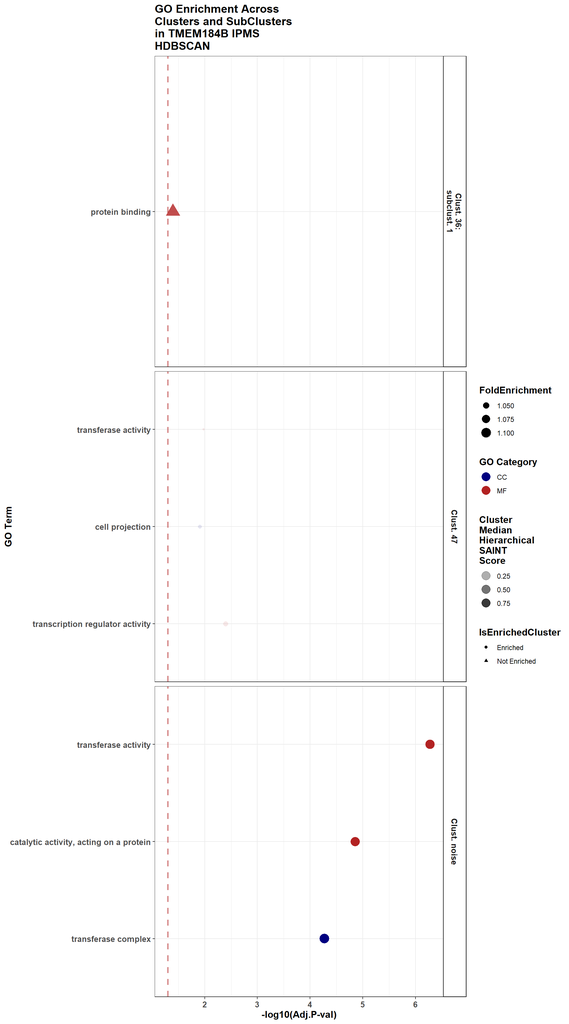

```r
global_enrichment_results_df |>
  dplyr::full_join(subcluster_enrichment_results_df) |>
  dplyr::filter(!is.na(GO_Term)) |>
  dplyr::filter(!is.na(GO_Category)) |>
  dplyr::filter(!is.na(cluster_median_hSAINT_score)) |>
  dplyr::mutate(
    Tier = dplyr::case_when(
      is.na(subcluster) ~ paste0('Clust. ', cluster),
      TRUE ~ paste0('Clust. ', cluster,
                    ':\nsubclust. ',
                    gsub(subcluster, pattern = 'sub', replacement = ''))
      ),
    is_enriched = dplyr::case_when(is.na(subcluster) ~ 'Enriched',
                                   TRUE ~ 'Not Enriched')
    ) |>
  dplyr::group_by(cluster) |>
  dplyr::slice_head(n = 3) |>
  dplyr::arrange(p.adjust) |>
  ggplot2::ggplot(
    ggplot2::aes(
      x = -log10(p.adjust),
      y = forcats::fct_rev(forcats::fct_infreq(GO_Term, cluster_median_hSAINT_score)),
      color = GO_Category,
      size = FoldEnrichment,
      alpha = cluster_median_hSAINT_score,
      shape = is_enriched,
    )
  ) +
  ggplot2::geom_vline(xintercept = -log10(0.05),
                      linetype = 'dashed',
                      color = 'firebrick',
                      size = 1,
                      alpha = 0.5) +
  ggplot2::geom_point() +
  ggplot2::facet_grid(Tier ~ ., scales = 'free_y') +
  ggplot2::labs(title = 'GO Enrichment Across\nClusters and SubClusters\nin TMEM184B IPMS\nHDBSCAN',
                x = '-log10(Adj.P-val)',
                y = 'GO Term',
                alpha = 'Cluster\nMedian\nHierarchical\nSAINT\nScore',
                size = 'FoldEnrichment',
                color = 'GO Category',
                shape = 'IsEnrichedCluster') +
  ggplot2::theme_bw() +
  ggplot2::theme(title = ggplot2::element_text(face = 'bold', size = 12),
                 axis.text = ggplot2::element_text(face = 'bold', size = 10),
                 strip.text = ggplot2::element_text(face = 'bold', size = 10),
                 strip.background = ggplot2::element_rect(color = 'black',
                                                          fill = 'white')) +
  ggplot2::guides(#shape = ggplot2::guide_legend(override.aes = list(size = 4, shape = c(19, 17))),
                  color = ggplot2::guide_legend(override.aes = list(size = 5,
                                                                    shape = 19,
                                                                    color = c('navy',
                                                                              'firebrick'))),
                  alpha = ggplot2::guide_legend(override.aes = list(size = 5,
                                                                    shape = 19)),
                  size = ggplot2::guide_legend(override.aes = list(shape = 19))
                  # size = 'none'
                  ) +
  ggplot2::scale_color_manual(values = c('navy',
                                        'firebrick'))
```

## Cluster GO (similarity) Network

```r
coords <- igraph::layout_with_fr(g)
coords <- coords*200

visNetwork::visNetwork(
  nodes = data.frame(
    id    = igraph::V(g)$name,
    label = igraph::V(g)$name,
    size = scales::rescale(
      (\(x){ x[is.na(x)] <- 0; x })(igraph::V(g)$cluster_hSAINT_score_mass),
      to = c(20, 60)
    ),
    x = coords[,1],
    y = coords[,2],
    group = base::interaction(
                        {
                          x <- igraph::V(g)$cluster
                          if (length(x) == 0) rep("", igraph::vcount(g)) else x
                        },
                        {
                          x <- igraph::V(g)$subcluster
                          if (length(x) == 0) {
                            rep("", igraph::vcount(g))
                          } else {
                            ifelse(nzchar(x), x, igraph::V(g)$cluster)
                          }
                        },
                        drop = TRUE,
                        lex.order = TRUE
                      ),
    title = sapply(
      igraph::V(g),
      function(v) {
        incoming_edges <- igraph::incident(g, v, mode = "all")
        incoming_edges <- incoming_edges[
          igraph::ends(g, incoming_edges)[,2] == igraph::V(g)[v]$name
        ]
        raw_gene_strings <- igraph::E(g)[incoming_edges]$geneID
        raw_gene_strings <- unlist(raw_gene_strings, use.names = FALSE)

        genes <- raw_gene_strings |>
          as.character() |>
          (\(x) x[!is.na(x)])() |>
          strsplit("\\\\") |>
          unlist() |>
          (\(x) x[nzchar(x)])() |>
          unique()

        term <- igraph::V(g)[v]$name
        saint_value <- igraph::V(g)[v]$cluster_hSAINT_score_mass
        if (is.na(saint_value)) saint_value <- 0
        is_module <- nzchar(igraph::V(g)[v]$subcluster)

        if (is_module) {
          paste0(
            "<div style='background-color:#ffffff;color:#1f4e79;",
            "padding:6px 10px;border-radius:6px;",
            "border:1px solid #1f4e79;font-size:12px;'>",
            "<b>", term, "</b><br>",
            "<b>SAINT mass:</b> ", signif(saint_value, 3), "<br>",
            if (length(genes) > 0)
              paste0("<u>Proteins:</u><br>", paste(genes, collapse = "<br>"))
            else "",
            "</div>"
          )
        } else {
          paste0(
            "<div style='background-color:#ffffff;color:#1f4e79;",
            "padding:6px 10px;border-radius:6px;",
            "border:1px solid #1f4e79;font-size:12px;'>",
            "<b>", term, "</b><br>",
            if (length(genes) > 0)
              paste0("<u>Proteins:</u><br>", paste(genes, collapse = "<br>"))
            else "",
            "</div>"
          )
        }
      }
    )
  ),
  edges = data.frame(
    from  = igraph::as_data_frame(g, "edges")$from,
    to    = igraph::as_data_frame(g, "edges")$to,
    value = igraph::E(g)$weight,
    title = vapply(
      seq_along(igraph::E(g)),
      function(i) {
        paste0(
          "<div style='background-color:#ffffff;color:#1f4e79;",
          "padding:6px 10px;border-radius:6px;",
          "border:1px solid #1f4e79;font-size:12px;'>",
          "<b>p.adjust:</b> ", signif(igraph::E(g)$p.adjust[i], 3), "<br>",
          "<b>weight:</b> ", signif(igraph::E(g)$weight[i], 3),
          "</div>"
        )
      },
      FUN.VALUE = character(1)
    )
  )
) |>
  # visNetwork::visNodes(color = NULL) |>
  visNetwork::visEdges(arrows = "to") |>
  visNetwork::visNodes(
    scaling = list(min = 5, max = 40),
    shadow  = TRUE
  ) |>
  visNetwork::visLayout(randomSeed = 1) |>
  visNetwork::visPhysics(enabled = FALSE) |>
  visNetwork::visInteraction(
    dragView = TRUE,
    zoomView = TRUE
  ) |>
  visNetwork::visOptions(nodesIdSelection = TRUE)
```

[interactive chart not shown]

```r
rm(coords)
```

Clusters with **enriched** `GO Terms` are **blue**

Here, only the enriched sub-clusters were included: the clusters with that did not reach significant enrichment broadly, but did reach significant enrichment when that cluster was broken up. These `Enriched` **sub-clusters** are **non-blue** and the top 5 (or fewer) most significantly enriched `GO Terms`

# Results Tables

## Clustering Results Table by Protein

```r
DT::datatable(
  protein_cluster_df |>
    dplyr::full_join(GO_df |>
                       dplyr::mutate(Protein = stringr::str_split(geneID,
                                                                  pattern = '/')) |>
                       tidyr::unnest_longer(Protein) |>
                       dplyr::distinct(Protein, .keep_all = T) |>
                       dplyr::relocate(c(Protein, cluster, subcluster), .before = 1) |>
                       dplyr::select(-c(Count:weight))
                     ) |>
    dplyr::filter(!is.na(GO_Term)) |>
    dplyr::filter(!is.na(GO_Category))
)
```

|  | Protein | cluster | cluster_class | protein_hSAINT_score | protein_contam_flag | protein_lit_flag | protein_CRAPome_flag | protein_stat_class | cluster_mean_hSAINT_score | cluster_median_hSAINT_score | cluster_hSAINT_score_mass | cluster_size | cluster_clean_n | cluster_clean_fraction | cluster_contam_perc | cluster_mean_rank | cluster_median_rank | cluster_total_rank | cluster_lit_flag_perc | cluster_CRAPome_flag_perc | subcluster | GO_Category | GO_ID | GO_Term | GeneRatio | BgRatio | RichFactor | FoldEnrichment | zScore | … |
| --- | --- | --- | --- | --- | --- | --- | --- | --- | --- | --- | --- | --- | --- | --- | --- | --- | --- | --- | --- | --- | --- | --- | --- | --- | --- | --- | --- | --- | --- | --- |
| 1 | AAAS | noise | High hSAINT, High Contamination | 1 | 0 | 0 | 0 | High hSAINT, Low Contamination | 0.765 | 0.992 | 1972.203 | 2577 | 320 | 12.42 | 12.418 | 36 | 26 | 1 | 8.964 | 3.454 |  | CC | GO:0005815 | microtubule organizing center | 252/2218 | 265/2536 | 0.9509433962264151 | 1.087282440410365 | 3.964582350041393 | … |
| 2 | AARS1 | noise | High hSAINT, High Contamination | 1 | 0 | 0 | 0 | High hSAINT, Low Contamination | 0.765 | 0.992 | 1972.203 | 2577 | 320 | 12.42 | 12.418 | 36 | 26 | 1 | 8.964 | 3.454 |  | MF | GO:0140096 | catalytic activity, acting on a protein | 353/2204 | 371/2522 | 0.9514824797843666 | 1.088765342112601 | 4.87291503246391 | … |
| 3 | AARS2 | noise | High hSAINT, High Contamination | 1 | 0 | 0 | 0 | High hSAINT, Low Contamination | 0.765 | 0.992 | 1972.203 | 2577 | 320 | 12.42 | 12.418 | 36 | 26 | 1 | 8.964 | 3.454 |  | MF | GO:0140096 | catalytic activity, acting on a protein | 353/2204 | 371/2522 | 0.9514824797843666 | 1.088765342112601 | 4.87291503246391 | … |
| 4 | AASS | noise | High hSAINT, High Contamination | 1 | 0 | 0 | 0 | High hSAINT, Low Contamination | 0.765 | 0.992 | 1972.203 | 2577 | 320 | 12.42 | 12.418 | 36 | 26 | 1 | 8.964 | 3.454 |  | MF | GO:0030674 | protein-macromolecule adaptor activity | 307/2204 | 329/2522 | 0.9331306990881459 | 1.067765709210664 | 3.469503092451981 | … |
| 5 | ABCB10 | noise | High hSAINT, High Contamination | 1 | 0 | 0 | 0 | High hSAINT, Low Contamination | 0.765 | 0.992 | 1972.203 | 2577 | 320 | 12.42 | 12.418 | 36 | 26 | 1 | 8.964 | 3.454 |  | MF | GO:0030554 | adenyl nucleotide binding | 430/2204 | 464/2522 | 0.9267241379310345 | 1.060434789411102 | 3.793167109306226 | … |
| 6 | ABCB7 | noise | High hSAINT, High Contamination | 1 | 0 | 0 | 0 | High hSAINT, Low Contamination | 0.765 | 0.992 | 1972.203 | 2577 | 320 | 12.42 | 12.418 | 36 | 26 | 1 | 8.964 | 3.454 |  | MF | GO:0030554 | adenyl nucleotide binding | 430/2204 | 464/2522 | 0.9267241379310345 | 1.060434789411102 | 3.793167109306226 | … |
| 7 | ABCE1 | noise | High hSAINT, High Contamination | 1 | 0 | 0 | 0 | High hSAINT, Low Contamination | 0.765 | 0.992 | 1972.203 | 2577 | 320 | 12.42 | 12.418 | 36 | 26 | 1 | 8.964 | 3.454 |  | BP | GO:0043412 | macromolecule modification | 411/2188 | 436/2503 | 0.9426605504587156 | 1.078372649816346 | 4.745145914648687 | … |
| 8 | ABCF1 | noise | High hSAINT, High Contamination | 1 | 0 | 0 | 0 | High hSAINT, Low Contamination | 0.765 | 0.992 | 1972.203 | 2577 | 320 | 12.42 | 12.418 | 36 | 26 | 1 | 8.964 | 3.454 |  | MF | GO:0030554 | adenyl nucleotide binding | 430/2204 | 464/2522 | 0.9267241379310345 | 1.060434789411102 | 3.793167109306226 | … |
| 9 | ACACA | noise | High hSAINT, High Contamination | 1 | 0 | 0 | 0 | High hSAINT, Low Contamination | 0.765 | 0.992 | 1972.203 | 2577 | 320 | 12.42 | 12.418 | 36 | 26 | 1 | 8.964 | 3.454 |  | MF | GO:0030554 | adenyl nucleotide binding | 430/2204 | 464/2522 | 0.9267241379310345 | 1.060434789411102 | 3.793167109306226 | … |
| 10 | ACIN1 | noise | High hSAINT, High Contamination | 1 | 0 | 0 | 0 | High hSAINT, Low Contamination | 0.765 | 0.992 | 1972.203 | 2577 | 320 | 12.42 | 12.418 | 36 | 26 | 1 | 8.964 | 3.454 |  | BP | GO:0051239 | regulation of multicellular organismal process | 361/2188 | 386/2503 | 0.9352331606217616 | 1.069875960254236 | 3.933444683994762 | … |

[output cut: 3406 more lines]

This table exists as HDBSCAN_protein_level_GO_GSEA.rda in Endo/analysis/R/HDBSCAN/

## Clustering Results Table by Cluster

```r
DT::datatable(
  GO_df |>
    dplyr::full_join(cluster_scores) |>
    dplyr::select(-c(Tier:weight))
)
```

|  | GO_Category | cluster | cluster_class | GO_ID | GO_Term | GeneRatio | BgRatio | RichFactor | FoldEnrichment | zScore | pvalue | p.adjust | qvalue | geneID | Count | cluster_mean_hSAINT_score | cluster_median_hSAINT_score | cluster_hSAINT_score_mass | cluster_size | cluster_contam_perc | cluster_mean_rank | cluster_median_rank | cluster_total_rank | cluster_lit_flag_perc | cluster_CRAPome_flag_perc | subcluster |
| --- | --- | --- | --- | --- | --- | --- | --- | --- | --- | --- | --- | --- | --- | --- | --- | --- | --- | --- | --- | --- | --- | --- | --- | --- | --- | --- |
| 1 | MF | 47 | Low hSAINT, Low Contamination | GO:0140110 | transcription regulator activity | 288/2660 | 288/2762 | 1 | 1.038345864661654 | 3.510660776984621 | 1.059621119257835e-05 | 0.004026560253179772 | 0.003870405561920723 | ADNP2/AEBP2/AHDC1/AIP/AJUBA/ARGLU1/ARID3A/ARID5B/ARNT/ASAH1/…… | 288 | 0.03909080937341439 | 0.01128691686180363 | 113.480619611022 | 2903 | 3.582500861178092 | 48 | 48 | 2 | 3.582500861178092 | 0 |  |
| 2 | MF | 47 | Low hSAINT, Low Contamination | GO:0016740 | transferase activity | 457/2660 | 461/2762 | 0.9913232104121475 | 1.029336356074568 | 3.523483624297106 | 5.478676175700249e-05 | 0.01040948473383047 | 0.01000579280509467 | ACAT2/AGPAT3/AGPAT4/AK3/AK6/AKT3/ALAS1/ALG11/ALG12/ALG13/ALG…… | 457 | 0.03909080937341439 | 0.01128691686180363 | 113.480619611022 | 2903 | 3.582500861178092 | 48 | 48 | 2 | 3.582500861178092 | 0 |  |
| 3 | CC | 47 | Low hSAINT, Low Contamination | GO:0042995 | cell projection | 364/2665 | 366/2768 | 0.994535519125683 | 1.032973477275756 | 3.443922453380672 | 5.045993563310874e-05 | 0.0123869416178242 | 0.01213243929919173 | ABCB1/ABLIM1/ACADM/ACAP2/ACTR10/ACTR3B/ADAM15/AGFG1/AJUBA/AK…… | 364 | 0.03909080937341439 | 0.01128691686180363 | 113.480619611022 | 2903 | 3.582500861178092 | 48 | 48 | 2 | 3.582500861178092 | 0 |  |
| 4 | CC | 47 | Low hSAINT, Low Contamination | GO:0120025 | plasma membrane bounded cell projection | 349/2665 | 351/2768 | 0.9943019943019943 | 1.032730926914792 | 3.337398844911062 | 8.873365001679651e-05 | 0.0123869416178242 | 0.01213243929919173 | ABCB1/ABLIM1/ACADM/ACAP2/ACTR10/ACTR3B/ADAM15/AJUBA/AKT3/ALS…… | 349 | 0.03909080937341439 | 0.01128691686180363 | 113.480619611022 | 2903 | 3.582500861178092 | 48 | 48 | 2 | 3.582500861178092 | 0 |  |
| 5 | CC | 47 | Low hSAINT, Low Contamination | GO:0098588 | bounding membrane of organelle | 393/2665 | 396/2768 | 0.9924242424242424 | 1.030780601512309 | 3.365130625435864 | 9.936049426062193e-05 | 0.0123869416178242 | 0.01213243929919173 | ABCA3/ABCC10/ABCC5/ABCD1/ABCD4/ABHD6/ACAP2/ACOX1/AGPAT3/AGPA…… | 393 | 0.03909080937341439 | 0.01128691686180363 | 113.480619611022 | 2903 | 3.582500861178092 | 48 | 48 | 2 | 3.582500861178092 | 0 |  |
| 6 | CC | 47 | Low hSAINT, Low Contamination | GO:1990234 | transferase complex | 265/2665 | 266/2768 | 0.9962406015037594 | 1.034744459648182 | 3.031218908583717 | 0.000305134377460378 | 0.02853006429254534 | 0.02794388509373988 | ABHD11/AEBP2/ALG13/AMN1/ANAPC10/ANAPC16/ANAPC4/ANKRD9/ARMC5/…… | 265 | 0.03909080937341439 | 0.01128691686180363 | 113.480619611022 | 2903 | 3.582500861178092 | 48 | 48 | 2 | 3.582500861178092 | 0 |  |
| 7 | MF | noise | High hSAINT, High Contamination | GO:0016740 | transferase activity | 369/2204 | 385/2522 | 0.9584415584415584 | 1.096728498361892 | 5.427017316600869 | 1.318200075268399e-09 | 5.285982301826279e-07 | 4.662265529370336e-07 | AAK1/ABHD14B/ABL1/ABL2/ACLY/ADCK1/AGK/AGPAT1/AGPAT2/AGPAT5/A…… | 369 | 0.7653095293515406 | 0.9919940121872541 | 1972.20265713892 | 2577 | 12.41753977493209 | 36 | 26 | 1 | 8.963911525029102 | 3.453628249902988 |  |
| 8 | MF | noise | High hSAINT, High Contamination | GO:0140096 | catalytic activity, acting on a protein | 353/2204 | 371/2522 | 0.9514824797843666 | 1.088765342112601 | 4.87291503246391 | 7.031901368541302e-08 | 1.409896224392531e-05 | 1.243536242015725e-05 | AAK1/AARS1/AARS2/ABHD12/ABHD14B/ABHD17B/ABL1/ABL2/ACP1/ADCK1…… | 353 | 0.7653095293515406 | 0.9919940121872541 | 1972.20265713892 | 2577 | 12.41753977493209 | 36 | 26 | 1 | 8.963911525029102 | 3.453628249902988 |  |
| 9 | CC | noise | High hSAINT, High Contamination | GO:1990234 | transferase complex | 237/2218 | 245/2536 | 0.9673469387755103 | 1.106037798347473 | 4.610917930232713 | 1.335536155849739e-07 | 5.302078538723464e-05 | 4.470531553265443e-05 | ACTBL2/ACTG1/ACTL6A/AMBRA1/AMFR/ANAPC1/ANAPC2/ARIH1/ARIH2/AS…… | 237 | 0.7653095293515406 | 0.9919940121872541 | 1972.20265713892 | 2577 | 12.41753977493209 | 36 | 26 | 1 | 8.963911525029102 | 3.453628249902988 |  |
| 10 | BP | noise | High hSAINT, High Contamination | GO:0043412 | macromolecule modification | 411/2188 | 436/2503 | 0.9426605504587156 | 1.078372649816346 | 4.745145914648687 | 2.348666284444232e-07 | 0.0002964838620430709 | 0.0002697756759111024 | AAK1/AARS1/ABCE1/ABHD12/ABHD17B/ABI1/ABL1/ABL2/ABRAXAS2/AGTP…… | 411 | 0.7653095293515406 | 0.9919940121872541 | 1972.20265713892 | 2577 | 12.41753977493209 | 36 | 26 | 1 | 8.963911525029102 | 3.453628249902988 |  |

[output cut: 132 more lines]

This table exists as HDBSCAN_cluster_level_GO_GSEA.rda in Endo/analysis/R/HDBSCAN/

# Summary

The largest clusters, at least one of which is “noise”, intuitively have the largest `cluster_hSAINT_score_mass`. However, when sorting this first by low contaminant clusters (`cluster_contam_perc`), **Cluster 25** has the highest volume of `hSAINT` signal across clusters, with some interesting potential candidates

**Cluster 29** had a `cluster_hSAINT_score_mass` higher than the overall `cluster_hSAINT_score_mass` median score and with zero contaminants

Few clusters returned enriched `GO Terms`, likely due to `HDBSCAN`’s tendency to create many smaller-sized clusters. When coupled with the contamination filter on cluster member proteins (further limiting the number of proteins available on which to detect enrichment), this reduces the vast majority of `GO Terms`

A more in-depth analysis of proteins across clusters where there is greater probability of interacting with `TMEM` is encouraged– collecting groups of proteins, related by localization or function, is useful for inferring data validity; however, data coherence **should not negate** investigating proteins with high `hSAINT` scores or are known/likely to interact with `TMEM` or related processes

Collectively, it appears the `hierarchical SAINT` model has done a fair job at delineating possible signal from noise